# *El impacto de Booktok en la intencion de compra de los consumidores*

### PRUEBA DE MULTICOLINEALIDAD

```python
import matplotlib.pyplot as plt
import numpy as np
import pandas as pd
import seaborn as sns
from statsmodels.stats.outliers_influence import variance_inflation_factor

variables_diagnostico = [
    "like",
    "condivisioni",
    "commentCount",
    "visualizzazioni",
    "durata_video",
    "Persona_Visibile",
    "Voce_Narrante",
]

df_vif = df_clean[variables_diagnostico].dropna().copy()
```

*Matriz de correlación de Pearson*

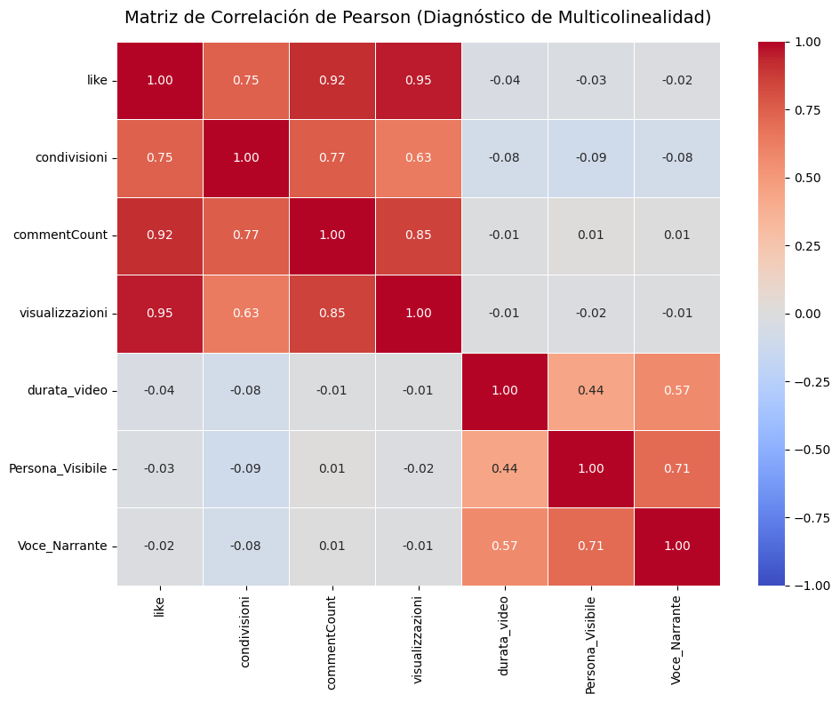

```python
matrice_corr = df_vif.corr()

plt.figure(figsize=(10, 8))

sns.heatmap(
    matrice_corr,
    annot=True,
    cmap="coolwarm",
    fmt=".2f",
    linewidths=0.5,
    vmin=-1,
    vmax=1,
)

plt.title(
    "Matriz de Correlación de Pearson (Diagnóstico de Multicolinealidad)",
    fontsize=14,
    pad=15,
)
plt.tight_layout()

plt.savefig("matriz_correlacion_booktok.png", dpi=300)
plt.show()
```

En este gráfico hay celdas que representan la intersección entre dos variables y contienen el coeficiente de correlación de Pearson (r). La diagonal principal (que va de arriba a la izquierda a abajo a la derecha) está compuesta por valores 1, lo que indica una correlación máxima. Esto resulta lógico, ya que cada variable está perfectamente correlacionada consigo misma. Además, hay diferentes colores que hacen referencia a distintas situaciones:

• El naranja intenso indica una fuerte correlación positiva y, por lo tanto, contiene valores cercanos a 1. Esto se debe al mecanismo según el cual, si una variable aumenta, la otra también tiende a aumentar;

• El blanco representa la ausencia de correlación, con valores cercanos a 0. En consecuencia, las dos variables no tienen una relación lineal entre sí;

• El azul contiene valores cercanos a -1 e indica una fuerte correlación negativa.

El gráfico permite detectar la presencia de multicolinealidad entre las variables (valores superiores a 0,7), lo que puede poner en riesgo la interpretación de los resultados del modelo de regresión. De hecho, el valor de la correlación entre «Persona_Visible» y «Voz_ Narradora» podría suponer un riesgo de multicolinealidad (0,709), lo que indica la presencia de una relación positiva entre las variables: si el creador muestra su rostro en el vídeo, casi siempre habla.

Calculamos el VIF (variance inflation factor)

```python
X = df_vif.copy()
X["Constante"] = 1.0

vif_data = pd.DataFrame()
vif_data["Variable"] = X.columns

vif_data["VIF"] = [
    variance_inflation_factor(X.values, i) for i in range(X.shape[1])
]

vif_data = vif_data[vif_data["Variable"] != "Constante"].reset_index(drop=True)

vif_data = vif_data.sort_values(by="VIF", ascending=False)

print("\n========================================================")
print("RESULTADOS DEL TEST VIF (VARIANCE INFLATION FACTOR):")
print("========================================================")
print(vif_data.to_string(index=False))
print("========================================================")
print(
    "Criterio de decisión:\n"
    " - VIF > 5: Indica presencia de multicolinealidad moderada.\n"
    " - VIF > 10: Indica multicolinealidad grave. Las variables deben ser excluidas."
)
```

```
========================================================
RESULTADOS DEL TEST VIF (VARIANCE INFLATION FACTOR):
========================================================
        Variable       VIF
            like 24.940654
 visualizzazioni 13.414037
    commentCount  7.578366
    condivisioni  2.877748
   Voce_Narrante  2.420716
Persona_Visibile  2.050054
    durata_video  1.500215
========================================================
Criterio de decisión:
 - VIF > 5: Indica presencia de multicolinealidad moderada.
 - VIF > 10: Indica multicolinealidad grave. Las variables deben ser excluidas.
```

Para comprender qué variables eliminar, resultó útil aplicar la prueba VIF (Variance Inflation Factor): si el valor de una variable es superior a 5 o 10, puede eliminarse, ya que no aporta ventajas al modelo y enturbia el análisis.